# EDA Notebook

## Introduction

Our business problem is to accurately forecast demand of Swire’s limited-release products, preventing both out-of-stocks and overproduction, and ensuring optimal production quantities that align with evolving consumer preferences. Achieving this goal will help Swire drive revenue growth and cost savings, expand market reach, and maintain a competitive edge in response to evolving consumer preferences and industry dynamics.

## Analytics approach

This problem is a supervised regression problem, where the target variable is units sold over a period of time as a metric for swire’s demand. The questions posed by Swire vary in character, but are all based on a desire to predict volume of sales (demand) over a period of time. The EDA and modeling process will explore the data available and a variety of modeling methods to determine the most useful inputs and methods.

## Questions to guide exploration.

> Can we make more meaning out of unit_sales if we group it by categorical data?

> Can we manipulate unit_sales and dollars_sales to find overall sales and average prices for grouped data?

> Will sum of overall dollar_sales be a better metric for demand and sum of unit_sales?

> Will the average price drop with larger orders?

> Will the average price be consistent or do we have outliers?

> How should the ITEM variable in the primary dataset be parsed to be able to provide insight and predictive value in the modeling process?

> How do prices change by region

> How does caloric preference change by region or state.

## Load libraries

```r
# Libraries

if (!require("pacman")) install.packages("pacman")
pacman::p_load(tidyverse, skimr, GGally, plotly, viridis,
               caret, DT, data.table, lightgbm, readr, e1071,
               ranger, parallel, mice, corrplot, ggplot2)
library(dplyr)
library(C50)
library(e1071)
library(psych)
library(caret)
library(rminer)
library(rmarkdown)
library(stringr)
#library(tictoc)
library(tidyverse)
library(matrixStats)
library(kableExtra)
#tic()

#Data
data <- read.csv("FACT_MARKET_DEMAND.csv")
```

## Random sampling for easier EDA

```r
# no missing columns in data as a whole
colSums(is.na(data))
```

```
##            DATE      MARKET_KEY CALORIC_SEGMENT        CATEGORY      UNIT_SALES
##               0               0               0               0               0
##    DOLLAR_SALES    MANUFACTURER           BRAND         PACKAGE            ITEM
##               0               0               0               0               0
```

```r
set.seed(50)
sdf <- data
```

## Data overview of target variable

> Quick look at unit sales to various categorical data

```r
str(sdf)
```

```
## 'data.frame':    24461424 obs. of  10 variables:
##  $ DATE           : chr  "2021-08-21" "2022-05-07" "2022-10-22" "2022-08-13" ...
##  $ MARKET_KEY     : int  524 637 628 216 210 278 220 499 754 895 ...
##  $ CALORIC_SEGMENT: chr  "DIET/LIGHT" "REGULAR" "DIET/LIGHT" "REGULAR" ...
##  $ CATEGORY       : chr  "SSD" "SSD" "ING ENHANCED WATER" "SSD" ...
##  $ UNIT_SALES     : num  69 4 1 3 4 112 21 3 19 57 ...
##  $ DOLLAR_SALES   : num  389.74 30.96 2.25 7.55 25.96 ...
##  $ MANUFACTURER   : chr  "SWIRE-CC" "COCOS" "JOLLYS" "COCOS" ...
##  $ BRAND          : chr  "DIET YAWN" "GORGEOUS ORANGEOUS" "DIGRESS FLAVORED" "CHERRY FIZZ" ...
##  $ PACKAGE        : chr  "12SMALL 12ONE CUP" "12SMALL 12ONE CUP" "20SMALL MULTI JUG" "1L MULTI JUG" ...
##  $ ITEM           : chr  "YAWN ZERO SUGAR GENTLE DRINK SUPER-JUICE  DURIAN  CUP 12 LIQUID SMALL X12" "GORGEOUS SUNSET OUS GENTLE DRINK AVOCADO  CUP 12 LIQUID SMALL X12" "DIGRESS ZERO NUTRIENT ENHANCED WATER BVRG PURPLE  ZERO CALORIE JUG 20 LIQUID SMALL " "KOOL! RED  GENTLE DRINK RED  COLA CONTOUR…
```

```r
sdf %>%
  group_by(MARKET_KEY)%>%
  summarise(n=sum(UNIT_SALES))%>%
  mutate(percentage=n/sum(n))%>%
  arrange(desc(n))
```

```
## # A tibble: 200 × 3
##    MARKET_KEY          n percentage
##         <int>      <dbl>      <dbl>
##  1       1811 418534683.    0.0981
##  2       1172 349157445.    0.0819
##  3       6802  80935294.    0.0190
##  4        441  59357239.    0.0139
##  5       1135  56681153.    0.0133
##  6        647  48503684.    0.0114
##  7        586  41669389.    0.00977
##  8        560  40943762.    0.00960
##  9        817  36508500.    0.00856
## 10        673  36231705.    0.00849
## # … with 190 more rows
```

```r
sdf %>%
  group_by(CALORIC_SEGMENT)%>%
  summarise(n=sum(UNIT_SALES))%>%
  mutate(percentage=n/sum(n))%>%
  arrange(desc(n))
```

```
## # A tibble: 3 × 3
##   CALORIC_SEGMENT           n percentage
##   <chr>                 <dbl>      <dbl>
## 1 "REGULAR"       2699684089.   0.633
## 2 "DIET/LIGHT"    1562434378.   0.366
## 3 ""                 3244135.   0.000761
```

```r
sdf %>%
  group_by(CATEGORY)%>%
  summarise(n=sum(UNIT_SALES))%>%
  mutate(percentage=n/sum(n))%>%
  arrange(desc(n))
```

```
## # A tibble: 5 × 3
##   CATEGORY                     n percentage
##   <chr>                    <dbl>      <dbl>
## 1 SSD                2696996876.    0.632
## 2 ENERGY             1198324442.    0.281
## 3 ING ENHANCED WATER  197299015.    0.0463
## 4 SPARKLING WATER     166177968.    0.0390
## 5 COFFEE                6564301     0.00154
```

```r
sdf %>%
  group_by(BRAND)%>%
  summarise(n=sum(UNIT_SALES))%>%
  mutate(percentage=n/sum(n))%>%
  arrange(desc(n))
```

```
## # A tibble: 319 × 3
##    BRAND                                 n percentage
##    <chr>                             <dbl>      <dbl>
##  1 BUBBLE JOY ADVANTAGEOUS      404310942.     0.0948
##  2 REAL-TIME                    268351647.     0.0629
##  3 PEPPY                        251184816.     0.0589
##  4 PAPI                         216457130.     0.0507
##  5 ELF BUBBLES                  177671835.     0.0417
##  6 REAL-TIME EDITIONS           172718827.     0.0405
##  7 DIET BUBBLE JOY ADVANTAGEOUS 168687013.     0.0395
##  8 HILL MOISTURE                167352606.     0.0392
##  9 MYTHICAL BEVERAGE ULTRA      147757133.     0.0346
## 10 MYTHICAL BEVERAGE            141581921.     0.0332
## # … with 309 more rows
```

```r
sdf %>%
  group_by(MANUFACTURER)%>%
  summarise(n=sum(UNIT_SALES))%>%
  mutate(percentage=n/sum(n))%>%
  arrange(desc(n))
```

```
## # A tibble: 8 × 3
##   MANUFACTURER           n percentage
##   <chr>              <dbl>      <dbl>
## 1 COCOS        1279323647.    0.300
## 2 JOLLYS       1043704245.    0.245
## 3 SWIRE-CC      834941867.    0.196
## 4 PONYS         475149320.    0.111
## 5 ALLYS         445086050.    0.104
## 6 BEARS          81974082.    0.0192
## 7 JORDYS         80589148.    0.0189
## 8 KEKES          24594243.    0.00577
```

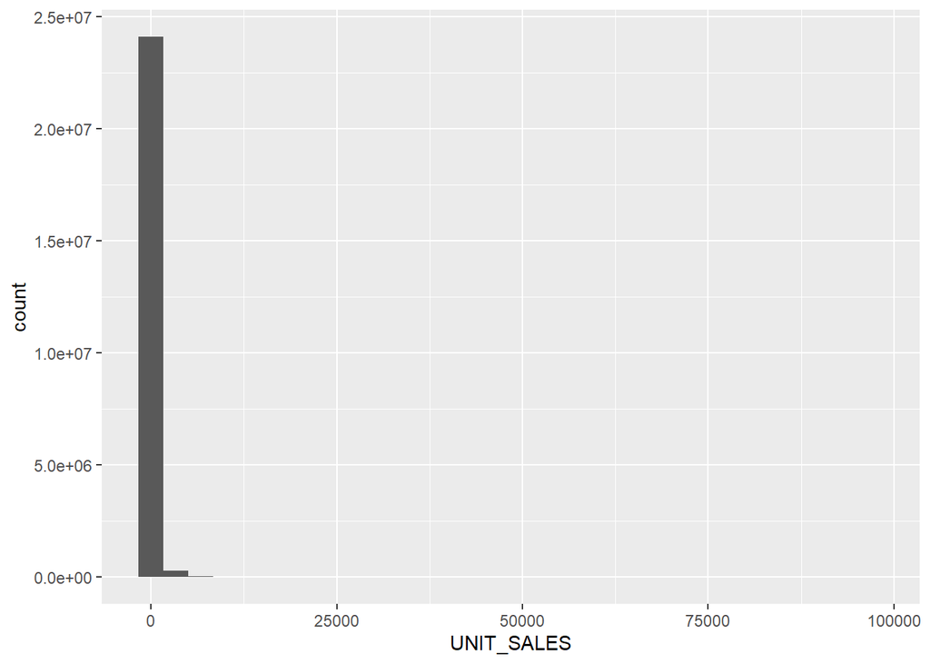

```r
ggplot(data = sdf,aes(UNIT_SALES))+
  geom_histogram()
```

> Looking at the overall structure of the data, we can see that there are a lot of categorical data. Our target variable, unit_sales is a number. Interesting enough, this is not an integer.

> Grouping by market key, we can see the amount of unit sales per market. This may be abstract now, but could give interesting information as we connect market_key with more familier area codes.

> SSD is the most popular category with Energy being second.

> Swire-CC is one of the largest manufacturers

> The histogram shows that there are some really large orders (unit sales) in the dataset that could be considered extreme values.